# Travail pratique d'apprentissage automatique 1

### Réalisé par Mulapi Tita Ketsia

Ce fichier réunit l'ensemble des travaux pratiques du cours d'apprentissage automatique 1 (2020-2021) du Master 1 Science de Données de l'Université de Rouen Normandie.

Nous réalisons ce travail ainsi que ce fichier dnas l'esprit de mettre en oeuvre une véritable reférence en terme d'algorithme de classification qui si'nscrit de ce fait dans nos annales.

1. **Perceptron : Un perceptron**

   Le perceptron est un neurone artificiel, une unité qui appartient à un réseau de neurones artificiel. Pour mieux comprendre ce concept, il est nécessaire de revenir à la définition de réseau de neurones.

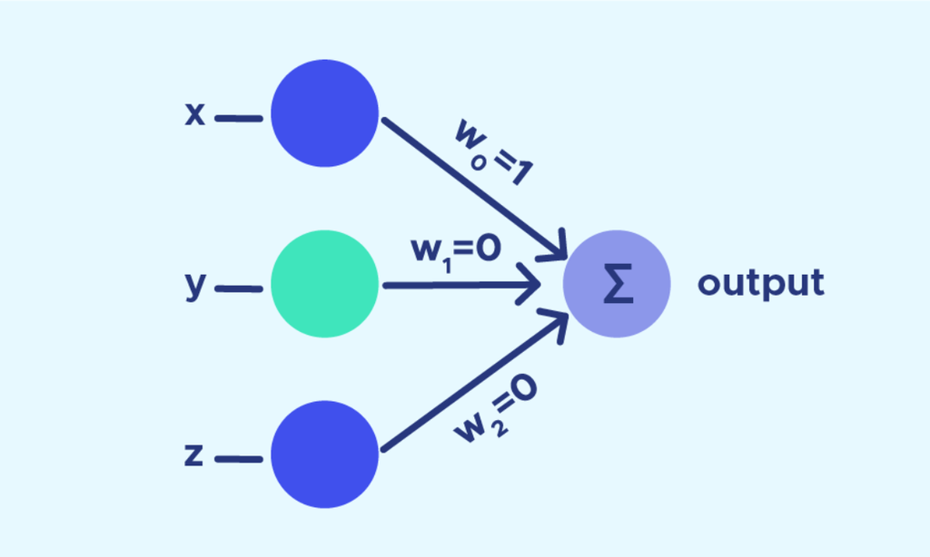

1. **Decision Tree : Les arbres de décisions**

   Un arbre de décision est un outil d'aide à la décision représentant un ensemble de choix sous la forme graphique d'un arbre. ... L'arbre de décision est un outil utilisé dans des domaines variés tels que la sécurité, la fouille de données, la médecine, etc. Il a l'avantage d'être lisible et rapide à exécuter.

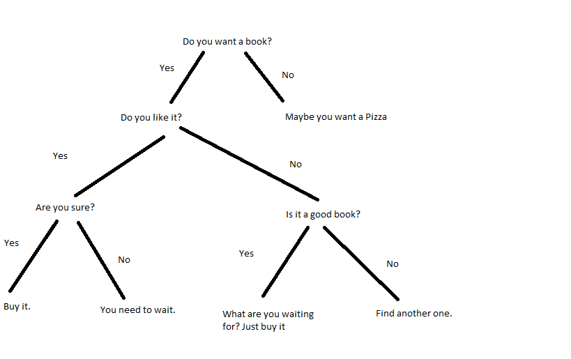

1. **Support Vector Machine (SVM) : Les machines à vecteurs de support**

   Ce sont des algorithmes d'apprentissage automatique (modèle ou intelligence artificielle), utilisés en machine learning pour résoudre des problèmes de classification, de régression ou de détection d'anomalie.

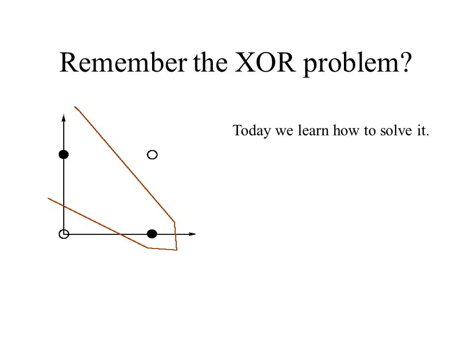

1. **Multi Layer Perceptron (MLP) : Perceptron Multi Couche**

   Le perceptron multicouche (multilayer perceptron MLP) est un type de réseau neuronal artificiel organisé en plusieurs couches au sein desquelles une information circule de la couche d'entrée vers la couche de sortie uniquement ; il s'agit donc d'un réseau à propagation directe (feedforward).

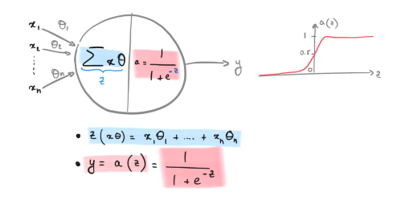

#### Dans ce TP et uniquement dans ce travail, ils nous servirons à faire de la classification.

```
                                                                        Source des définitions : Wikipedia.
```

# 1) Travail Pratique 1 : le perceptron

Dans ce travail pratique, nous allons principalement nous intérresser à la mise en place d'une séparation linéaire à l'aide d'un perceptron.

C'est quoi un perceptron ?

Selon Wikipédia, le perceptron est un algorithme d'apprentissage supervisé de classifieurs binaires. Il a été inventé en 1957 par Frank Rosenblatt au laboratoire d'aéronautique de l'université Cornell. On dit aussi que le réseau de Neurones le plus simple qui existe porte le nom de perceptron.

A l'instar du travail réalisé l'année dernière en L3 Science des Données, notre travaille s'articulera au tour de 6 datasets, reparti en 2 groupes dont 3 dédiés à l'apprentissage et, 3 dédiés aux test.

3 questions principales seront abordées, il s'agit notamment de savoir :

1. **Question 1** 🤔

Programmer l'algorithme d'apprentissage du perceptron vu en cours en cherchant un hyperplan qui sépare une classe d'une autre (soit pour 5 classes, 5*4/2 hyperplans à déterminer). Le tester sur le jeu de données TP1.

1. **Question 2** 🤔
   - Adapter l’algorithme pour qu’il converge vers une solution sur les jeux de données TP2 et TP3 (non linéairement séparables).
   - Evaluer les performances sur ces deux jeux de données.
1. **Question 3** 🤔

Après avoir supprimé des 3 jeux de données la classe centrale (classe ‘e’ ou 5),

```
3.1) Adapter votre algorithme de décision en cherchant un hyperplan qui sépare une classe de toutes les autres (soit pour 4 classes, 4 hyperplans à déterminer).

3.2) Evaluer les performances (taux de bonne classification en Top1, matrice de confusion) sur le jeu de données TP1 et comparer à la version one-vs-one.
```

1. **Conclusion** 🤔

Comparer l’ensemble des solutions possibles sur les 3 jeux de données.

# Importation des librairies 📥

```python
import pandas as pd
```

```python
import numpy as np
```

```python
import matplotlib.pyplot as plt
```

# Phase de pré-traitement ⛏️

```python
def pretraitement(path):
    with open(path, 'r') as f:
        lines = f.readlines()
    classes=[]
    XList=[]
    YList=[]
    for line in lines:
        line = line.split(" ")
        classes.append(line[0])
        XList.append(line[1])
        YList.append(line[2].replace("\n",""))
    df = pd.DataFrame({"classes":classes,"X":XList,"Y":YList})
    df.info()
    return df
```

```python
def getClasses(df):
    df.classes = df.classes.astype("int")
    df.X = df.X.astype("float")
    df.Y = df.Y.astype("float")
    w1 = df[df.classes==1].iloc[:,0:3]
    w2 = df[df.classes==2].iloc[:,0:3]
    w3 = df[df.classes==3].iloc[:,0:3]
    w4 = df[df.classes==4].iloc[:,0:3]
    w5 = df[df.classes==5].iloc[:,0:3]
    return w1, w2, w3, w4, w5, df
```

### Ouverture data app 1

```python
df_app1 = pretraitement("data_tp1_app.txt")
```

```
<class 'pandas.core.frame.DataFrame'>
RangeIndex: 500 entries, 0 to 499
Data columns (total 3 columns):
 #   Column   Non-Null Count  Dtype
---  ------   --------------  -----
 0   classes  500 non-null    object
 1   X        500 non-null    object
 2   Y        500 non-null    object
dtypes: object(3)
memory usage: 11.8+ KB
```

```python
w1, w2, w3, w4, w5, df_app1 = getClasses(df_app1)
```

```python
df_app1
```

|  | classes | X | Y |
| --- | --- | --- | --- |
| 0 | 1 | -6.315382 | 6.344938 |
| 1 | 1 | -4.943573 | 7.821684 |
| 2 | 1 | -8.920876 | 2.705258 |
| 3 | 1 | -5.661533 | 7.425065 |
| 4 | 1 | -5.918269 | 5.697313 |
| ... | ... | ... | ... |
| 495 | 5 | -1.446325 | -0.422072 |
| 496 | 5 | 0.261599 | 0.479059 |
| 497 | 5 | -2.243814 | -0.673345 |
| 498 | 5 | -0.489892 | 0.282347 |
| 499 | 5 | 0.310185 | 0.024044 |

500 rows × 3 columns

```python
w1
```

|  | classes | X | Y |
| --- | --- | --- | --- |
| 0 | 1 | -6.315382 | 6.344938 |
| 1 | 1 | -4.943573 | 7.821684 |
| 2 | 1 | -8.920876 | 2.705258 |
| 3 | 1 | -5.661533 | 7.425065 |
| 4 | 1 | -5.918269 | 5.697313 |
| ... | ... | ... | ... |
| 95 | 1 | -7.349321 | 4.544704 |
| 96 | 1 | -10.011338 | 3.986633 |
| 97 | 1 | -8.265909 | 4.298196 |
| 98 | 1 | -4.767163 | 7.536841 |
| 99 | 1 | -3.940310 | 8.777248 |

100 rows × 3 columns

```python
w3
```

|  | classes | X | Y |
| --- | --- | --- | --- |
| 200 | 3 | 9.135342 | -5.820299 |
| 201 | 3 | 7.580485 | -7.192279 |
| 202 | 3 | 6.424520 | -8.413679 |
| 203 | 3 | 6.382569 | -5.297024 |
| 204 | 3 | 6.375425 | -5.881410 |
| ... | ... | ... | ... |
| 295 | 3 | 8.977618 | -4.464873 |
| 296 | 3 | 5.345582 | -5.864768 |
| 297 | 3 | 7.170776 | -3.382814 |
| 298 | 3 | 3.426561 | -7.887567 |
| 299 | 3 | 8.309419 | -5.301970 |

100 rows × 3 columns

### Ouverture data dec 1

```python
df_dec1 = pretraitement("data_tp1_dec.txt")
```

```
<class 'pandas.core.frame.DataFrame'>
RangeIndex: 500 entries, 0 to 499
Data columns (total 3 columns):
 #   Column   Non-Null Count  Dtype
---  ------   --------------  -----
 0   classes  500 non-null    object
 1   X        500 non-null    object
 2   Y        500 non-null    object
dtypes: object(3)
memory usage: 11.8+ KB
```

```python
w1_test, w2_test, w3_test, w4_test, w5_test, df_dec1 = getClasses(df_dec1)
```

```python
df_dec1
```

|  | classes | X | Y |
| --- | --- | --- | --- |
| 0 | 1 | -4.840798 | 5.117552 |
| 1 | 1 | -2.458894 | 5.701029 |
| 2 | 1 | -5.195775 | 6.207984 |
| 3 | 1 | -6.059512 | 4.324269 |
| 4 | 1 | -5.864124 | 8.061702 |
| ... | ... | ... | ... |
| 495 | 5 | -0.532394 | -0.478236 |
| 496 | 5 | -0.596780 | -1.310213 |
| 497 | 5 | 0.645414 | 0.058871 |
| 498 | 5 | 0.679295 | -1.391780 |
| 499 | 5 | 0.998671 | 1.712854 |

500 rows × 3 columns

```python
w1
```

|  | classes | X | Y |
| --- | --- | --- | --- |
| 0 | 1 | -6.315382 | 6.344938 |
| 1 | 1 | -4.943573 | 7.821684 |
| 2 | 1 | -8.920876 | 2.705258 |
| 3 | 1 | -5.661533 | 7.425065 |
| 4 | 1 | -5.918269 | 5.697313 |
| ... | ... | ... | ... |
| 95 | 1 | -7.349321 | 4.544704 |
| 96 | 1 | -10.011338 | 3.986633 |
| 97 | 1 | -8.265909 | 4.298196 |
| 98 | 1 | -4.767163 | 7.536841 |
| 99 | 1 | -3.940310 | 8.777248 |

100 rows × 3 columns

## Visualisation des datasets

```python
def afficher_dataset(df):
    plt.figure(figsize=(15,8))
    for i in range(5):
        plt.plot(df[df.iloc[:,0]==i+1].iloc[:,0:3].iloc[:,1], df[df.iloc[:,0]==i+1].iloc[:,0:3].iloc[:,2], 'o', label="classes : "+str(i+1))
        plt.legend()
```

### dataset app 1

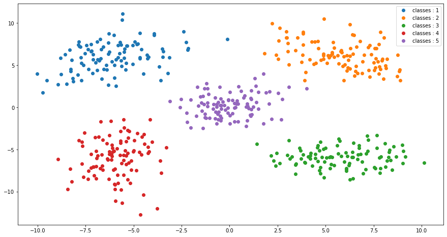

```python
afficher_dataset(df_app1)
```

### dataset test 1

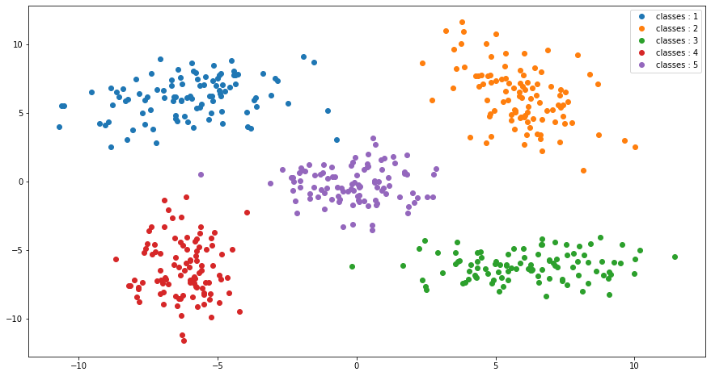

```python
afficher_dataset(df_dec1)
```

On met de coté notre dataset_test1 et on travaille avec notre dataset_app1 pour construire notre modèle afin de ressortir la droite.

### Fonction transformation

La transformation nous permet de passer d'une dimension à une autre afin de dégager, dans la mesure du possible, la solution optimale qui n'est rien d'autrez que la droite de séparation linéaire.

```python
def Xtransformation(W1, W2):
    new_w1 = W1.iloc[:,1:3]
    new_w1["Z"] = 1
    new_w2 = W2.iloc[:,1:3]
    new_w2 = W2.iloc[:,1:3]*-1
    new_w2["Z"] = -1
    return new_w1, new_w2
```

# Question 1 :

Programmer l'algorithme d'apprentissage du perceptron vu en cours en cherchant un hyperplan qui sépare une classe d'une autre (soit pour 5 classes, 5*4/2 = 10 hyperplans à déterminer). Le tester sur le jeu de données TP1.

## Réalisons 1 Perceptron

### Partie 1 (apprentissage) : W1 vs W2

#### Transformation des éléments de W1 & W2

```python
W1_y, W2_y = Xtransformation(w1, w2)
```

```python
W1_y
```

|  | X | Y | Z |
| --- | --- | --- | --- |
| 0 | -6.315382 | 6.344938 | 1 |
| 1 | -4.943573 | 7.821684 | 1 |
| 2 | -8.920876 | 2.705258 | 1 |
| 3 | -5.661533 | 7.425065 | 1 |
| 4 | -5.918269 | 5.697313 | 1 |
| ... | ... | ... | ... |
| 95 | -7.349321 | 4.544704 | 1 |
| 96 | -10.011338 | 3.986633 | 1 |
| 97 | -8.265909 | 4.298196 | 1 |
| 98 | -4.767163 | 7.536841 | 1 |
| 99 | -3.940310 | 8.777248 | 1 |

100 rows × 3 columns

```python
W2_y
```

|  | X | Y | Z |
| --- | --- | --- | --- |
| 100 | -3.043789 | -6.633307 | -1 |
| 101 | -7.284288 | -7.361353 | -1 |
| 102 | -7.383151 | -6.271942 | -1 |
| 103 | -2.526411 | -5.743564 | -1 |
| 104 | -5.834545 | -6.516551 | -1 |
| ... | ... | ... | ... |
| 195 | -6.589146 | -4.919101 | -1 |
| 196 | -6.501155 | -3.779524 | -1 |
| 197 | -7.291663 | -3.639030 | -1 |
| 198 | -3.837973 | -8.944113 | -1 |
| 199 | -2.953992 | -8.972900 | -1 |

100 rows × 3 columns

#### Vecteur A avec les a(i) = (0, 0 ,0) initialement

```python
A = np.array([0, 0, 0])
```

```python
A.shape
```

```
(3,)
```

```python
len(A)
```

```
3
```

```python
A
```

```
array([0, 0, 0])
```

## Mise en oeuvre et usage de l'algorithme de perceptron

```python
def perceptron(W1, W2, A):
    assert len(A)==W1.shape[1]
    W = np.array(pd.concat([W1, W2]))
    Vecteur_A = [A]
    #juste pour savoir combien d'itération a été fait !
    iteration = 0
    check = True
    while(check):
        #check = True
        check = False
        iteration += 1
        for i in range(len(W)):
            if(np.dot(W[i,0:3],A.reshape(-1,1))[0]<=0):
                check = True
                A = np.add(W[i,0:3],A)
                #print(A)
        Vecteur_A.append(A)
        n = len(Vecteur_A)
        #    check = False
    return Vecteur_A, n, iteration
```

```python
p_app1, n, iteration = perceptron(W1_y,W2_y,A)
```

```python
iteration
```

```
3
```

```python
n
```

```
4
```

```python
p_app1 # Les A[i] selon le nombre d'itération
```

```
[array([0, 0, 0]),
 array([-9.359171, -0.288369,  0.      ]),
 array([-12.527644,   1.184328,   0.      ]),
 array([-12.527644,   1.184328,   0.      ])]
```

```python
p_app1[len(p_app1)-1]
```

```
array([-12.527644,   1.184328,   0.      ])
```

## Approche One Versus One

### Affichons une sépartion linéaire à l'aide de fonctions factorisées

```python
def point_coeff_dir(A, precision):
    pointX = []
    pointY = []
    for i in range(precision[2], precision[1], precision[0]):
        Coefficient_directeur = (-A[0] /A[1]) * i - A[2] / A[1]
        #Coefficient_directeur = (-1/a[1])*(a[0]+a[2]*x)
        pointX.append(i)
        pointY.append(Coefficient_directeur)
    return pointX,pointY
```

```python
def uneSeparation(A, X, precision, txt, a, b):
    plt.figure(figsize=(10,5))
    pointX, pointY = point_coeff_dir(A, precision)
    plt.plot((X.iloc[0:99, 1:3]).iloc[:,0], (X.iloc[0:99, 1:3]).iloc[:, 1], 'o', label= 'classe '+str(a), color="black")
    plt.plot((X.iloc[100:199, 1:3]).iloc[:, 0], (X.iloc[100:199, 1:3]).iloc[:, 1], '+', label= 'classe '+str(b), color="red")
    plt.title(txt)
    plt.legend()
    plt.plot(pointX, pointY)
```

```python
def screenOvsO(w1,w2,txt, a, b):
    A = np.array([0,0,0])
    C1, C2 = Xtransformation(w1, w2)
    p_app1, n, iteration = perceptron(C1,C2,A)
    uneSeparation(p_app1[len(p_app1)-1], pd.concat([w1, w2]), [1, 10, -10],txt, a, b)
```

```python
def screenAll(w1,w2):
    A = np.array([0,0,0])
    C1, C2 = Xtransformation(w1, w2)
    p_app1, n, iteration = perceptron(C1,C2,A)
    precision=[1, 10, -10]
    pointX, pointY = point_coeff_dir(p_app1[len(p_app1)-1], precision)
    return pointX, pointY
```

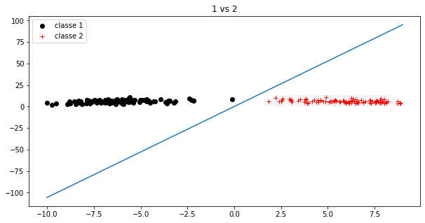

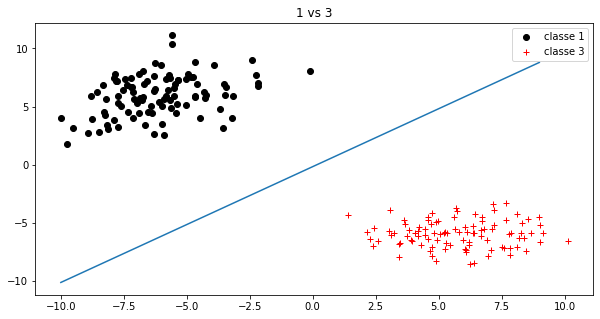

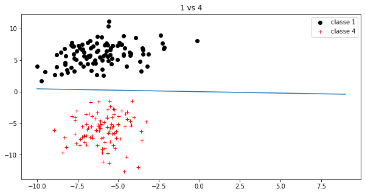

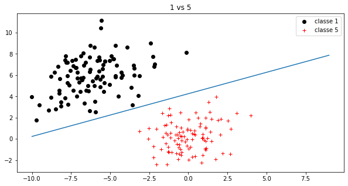

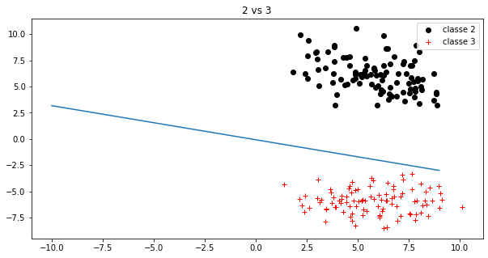

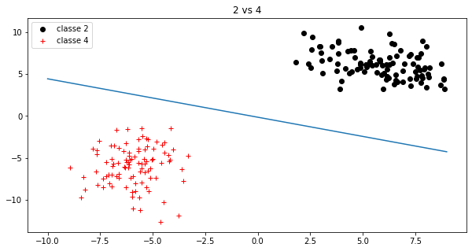

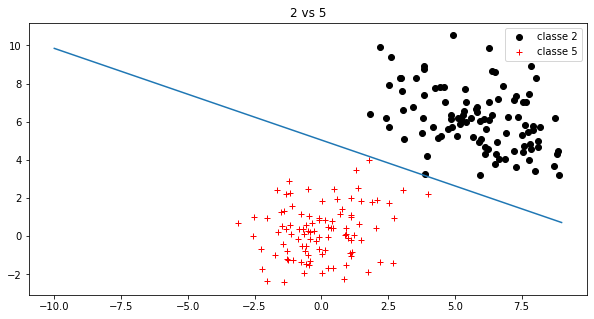

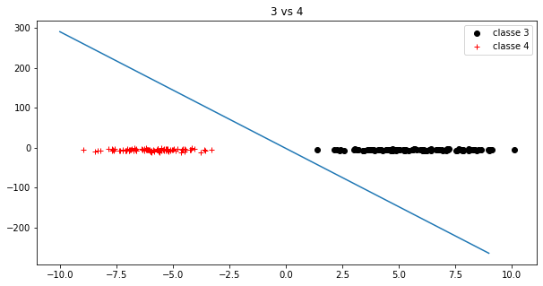

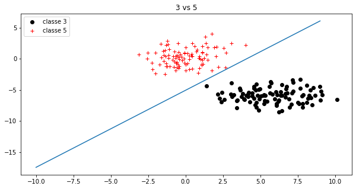

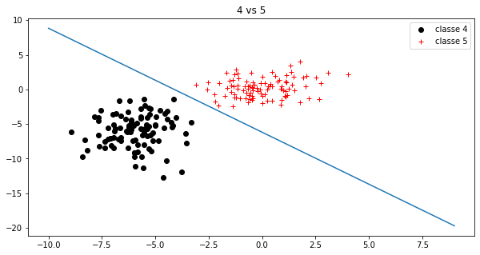

```python
screenOvsO(w1,w2, "1 vs 2", 1, 2)
screenOvsO(w1,w3, "1 vs 3", 1, 3)
screenOvsO(w1,w4, "1 vs 4", 1, 4)
screenOvsO(w1,w5, "1 vs 5", 1, 5)
screenOvsO(w2,w3, "2 vs 3", 2, 3)
screenOvsO(w2,w4, "2 vs 4", 2, 4)
screenOvsO(w2,w5, "2 vs 5", 2, 5)
screenOvsO(w3,w4, "3 vs 4", 3, 4)
screenOvsO(w3,w5, "3 vs 5", 3, 5)
screenOvsO(w4,w5, "4 vs 5", 4, 5)
```

## Affichage général

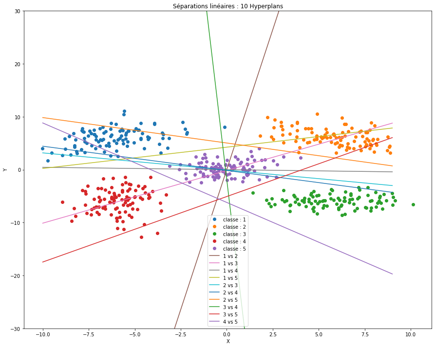

```python
plt.figure(figsize=(15,12))

for i in range(5):
    plt.plot(df_app1[df_app1.iloc[:,0]==i+1].iloc[:,0:3].iloc[:,1], df_app1[df_app1.iloc[:,0]==i+1].iloc[:,0:3].iloc[:,2], 'o', label="classe : "+str(i+1))
    plt.legend()

pointX1, pointY1 = screenAll(w1,w2)
plt.plot(pointX1, pointY1, label="1 vs 2")

pointX2, pointY2 = screenAll(w1,w3)
plt.plot(pointX2, pointY2,label="1 vs 3")

pointX3, pointY3 = screenAll(w1,w4)
plt.plot(pointX3, pointY3,label="1 vs 4")

pointX4, pointY4 = screenAll(w1,w5)
plt.plot(pointX4, pointY4, label="1 vs 5")

pointX5, pointY5 = screenAll(w2,w3)
plt.plot(pointX5, pointY5,label="2 vs 3")

pointX6, pointY6 = screenAll(w2,w4)
plt.plot(pointX6, pointY6,label="2 vs 4")

pointX7, pointY7 = screenAll(w2,w5)
plt.plot(pointX7, pointY7, label="2 vs 5")

pointX8, pointY8 = screenAll(w3,w4)
plt.plot(pointX8, pointY8,label="3 vs 4")

pointX9, pointY9 = screenAll(w3,w5)
plt.plot(pointX9, pointY9,label="3 vs 5")

pointX10, pointY10 = screenAll(w4,w5)
plt.plot(pointX10, pointY10, label="4 vs 5")

plt.ylim((-30,30))
plt.title("Séparations linéaires : 10 Hyperplans")
plt.ylabel("Y")
plt.xlabel("X")
plt.legend(loc="lower center")
plt.show()
```

### Partie 2 (Prediction) : Testons nos droites obtenues à l'aide des données d'apprentissage du dataset 1 sur les données de test (décision) du data_tp1_dec

#### Notre dataset de test

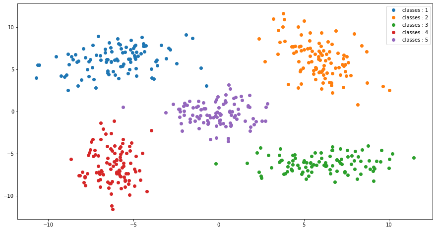

```python
afficher_dataset(df_dec1)
```

### 😎😎 Petit Bonus : avant d'achever ce "OvsO", on souhaite observer nos droites de séparation linéaires obtenues à l'aide du dataset_tp1_app sur le dataset_tp1_dec afin d'avoir une idée visuelle de ce que pourra être la performance de notre implémentation.

```python
def test_dec(w1,w2,a,b):
    A = np.array([0,0,0])
    plt.figure(figsize=(10,8))
    symbole = 'o'
    coleur = "black"
    for i in range(a-1,b,b-a):
        if(i==a-1):
            symbole = 'o'
            coleur = "black"
        elif(i==b-1):
            symbole = '+'
            coleur = "red"
        plt.plot(df_dec1[df_dec1.iloc[:,0]==i+1].iloc[:,0:3].iloc[:,1], df_dec1[df_dec1.iloc[:,0]==i+1].iloc[:,0:3].iloc[:,2], symbole, label="classe : "+str(i+1)+" du data_tp1_dec", color=coleur)
        plt.legend()

    pointX1, pointY1 = screenAll(w1,w2)
    plt.plot(pointX1, pointY1, label="droite "+str(a)+" vs " + str(b)+ " obtenue à l'aide du data_tp1_app")


    plt.title("Séparation linéaire data_tp1_dec : "+str(a)+" vs " + str(b)+ "")
    plt.ylabel("Y")
    plt.xlabel("X")
    plt.legend(loc="lower center")
    plt.show()
```

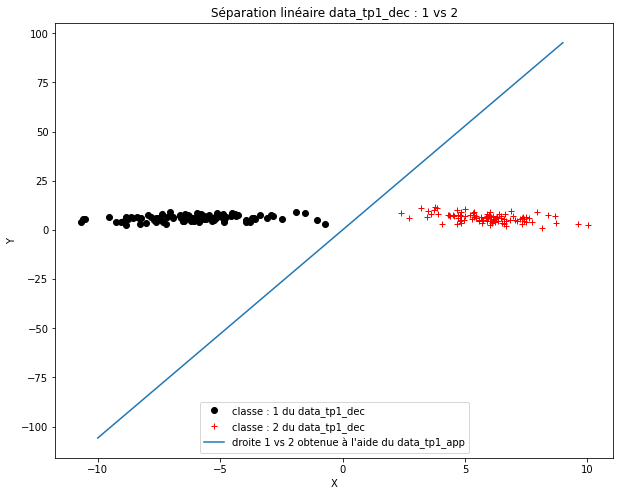

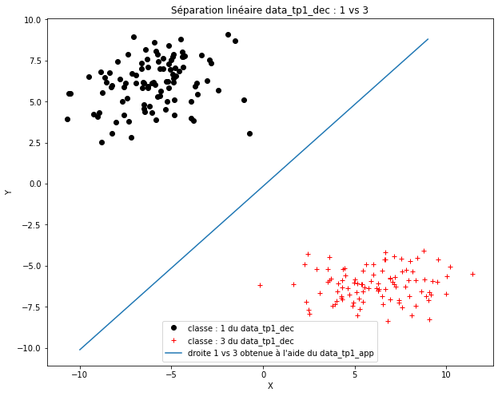

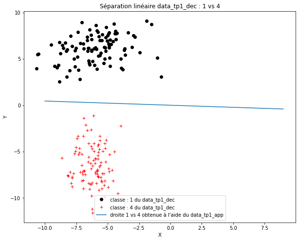

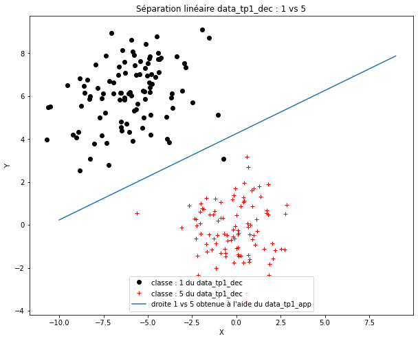

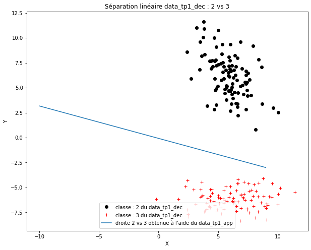

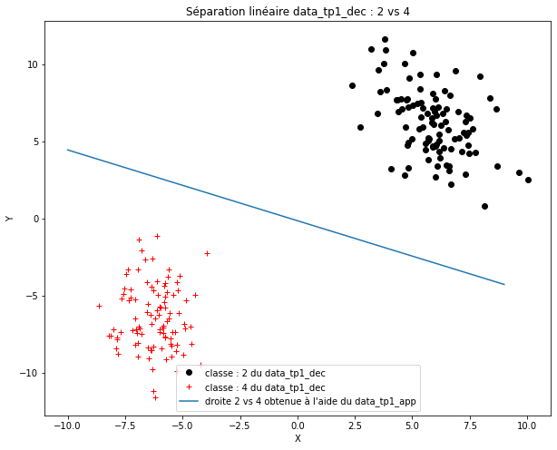

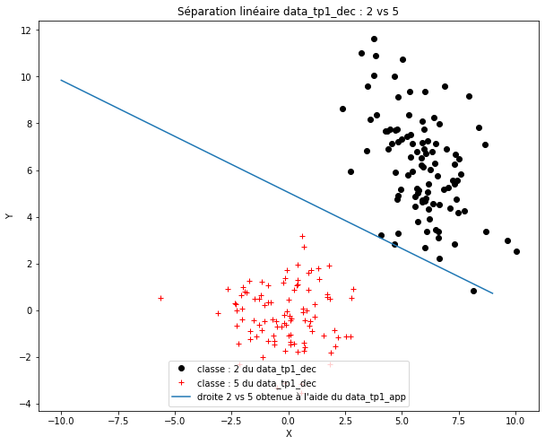

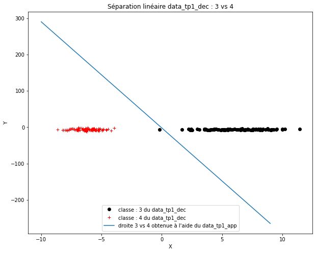

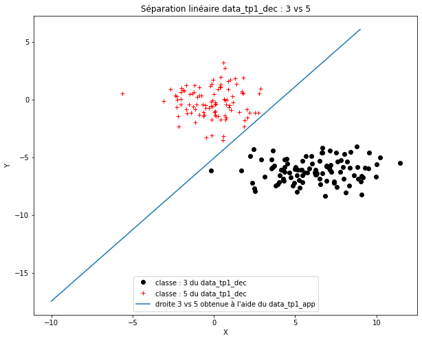

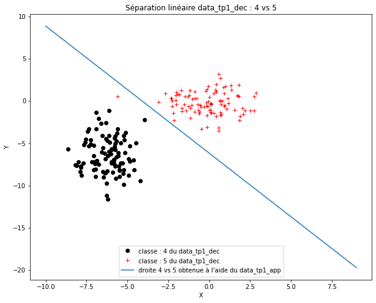

```python
test_dec(w1,w2,1,2)
test_dec(w1,w3,1,3)
test_dec(w1,w4,1,4)
test_dec(w1,w5,1,5)
test_dec(w2,w3,2,3)
test_dec(w2,w4,2,4)
test_dec(w2,w5,2,5)
test_dec(w3,w4,3,4)
test_dec(w3,w5,3,5)
test_dec(w4,w5,4,5)
```

# Question 2 :

### Adapter l’algorithme pour qu’il converge vers une solution sur les jeux de données TP2 et TP3 (non linéairement séparables). Evaluer les performances sur ces deux jeux de données.

C'est à dire, faire la même chose masi sur les jeux de données TP2 et TP3 puis en suite, évaluer les performances sur ces deux jeux de données.

### - TP2_app = W(i)_app2 (cette écriture se lit : classe i du jeux d'apprentissage 2)

```python
df_app2 = pretraitement("data_tp2_app.txt")
```

```
<class 'pandas.core.frame.DataFrame'>
RangeIndex: 500 entries, 0 to 499
Data columns (total 3 columns):
 #   Column   Non-Null Count  Dtype
---  ------   --------------  -----
 0   classes  500 non-null    object
 1   X        500 non-null    object
 2   Y        500 non-null    object
dtypes: object(3)
memory usage: 11.8+ KB
```

```python
w1_app2, w2_app2, w3_app2, w4_app2, w5_app2, df_app2 = getClasses(df_app2)
```

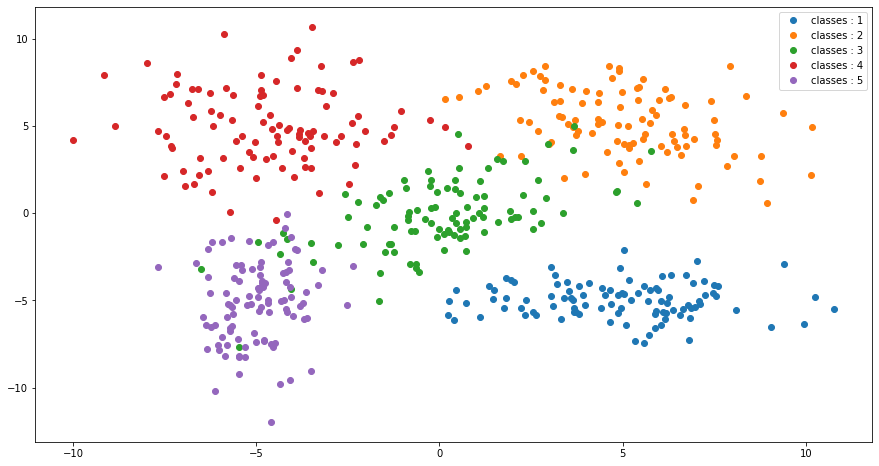

```python
afficher_dataset(df_app2)
```

### - TP3_app

```python
df_app3 = pretraitement("data_tp3_app.txt")
```

```
<class 'pandas.core.frame.DataFrame'>
RangeIndex: 500 entries, 0 to 499
Data columns (total 3 columns):
 #   Column   Non-Null Count  Dtype
---  ------   --------------  -----
 0   classes  500 non-null    object
 1   X        500 non-null    object
 2   Y        500 non-null    object
dtypes: object(3)
memory usage: 11.8+ KB
```

```python
w1_app3, w2_app3, w3_app3, w4_app3, w5_app3, df_app3 = getClasses(df_app3)
```

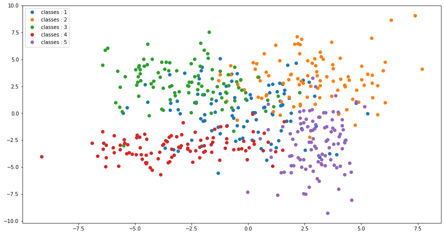

```python
afficher_dataset(df_app3)
```

## Score et Règle de décision : La droite d'équation pour évaluer le taux de bonne classification

> si *a(n-1).T* y(n) > 0* alors yn est bien classé ::: à retenir

> Sinon si *a(n-1).T* y(n) = 0* alors yn est sur la droite ::: à rejeter

> Sinon *a(n-1).T* y(n) < 0* alors yn est mal classé ::: à rejeter

```python
def equation(an,xn):
    # on utilise les données d'apprentissages pour
    # construire l'équation de la droite
    # avec, les coef ai trouvé à l'aide du perceptron
    a1 = an[0]
    a2 = an[1]
    a3 = an[2]
    x1 = xn[1]
    x2 = xn[2]
    # l'équation de la droite pour un W1 vs W2 est alors :
    #print(a1)
    eq = a1 * x1 + a2 * x2 + a3
    return eq
```

```python
def classification_accuracy(W1,last_a,W2,size1,size2):
    tx = 0
    size_of_data = size1+size2
    for point1 in W1:
        metrique1=equation(last_a,point1)
        if metrique1>0:
            tx = tx + 1
    for point2 in W2:
        metrique2=equation(last_a,point2)
        if metrique2>0:
            tx = tx + 1
    return (tx * 100)/ size_of_data
```